# Test with Ander’s hourly and Titta’s greenhouse spectra

Pedro J. Aphalo

2026-01-24

## Set up

```r
library(duckplyr)
library(photobiology)
library(photobiologyWavebands)
library(photobiologySensors)
library(photobiologyPlants)
library(photobiologySun)
library(photobiologyLamps)
library(ggspectra)
library(ggpmisc)
library(smatr)
library(rYoctoPuceInOut)
```

```r
theme_set(theme_bw())
photon_as_default()
```

## AS7343 spectral response

The AS7343 sensor has 13 channels covering wavelengths in the range 370-900 nm.

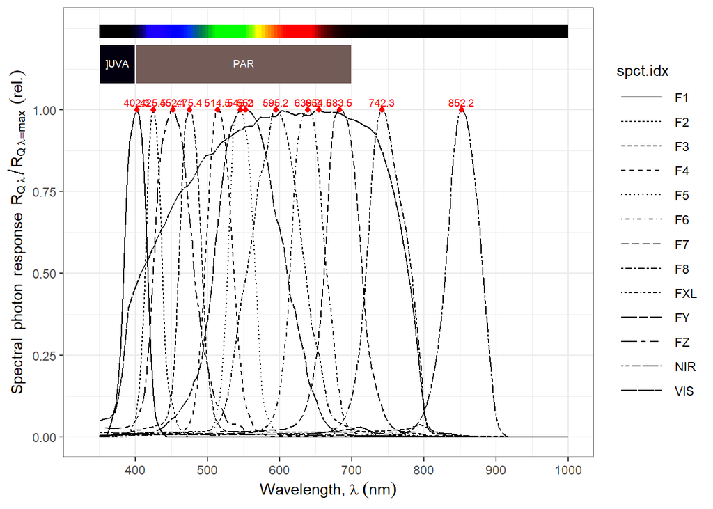

```r
ams_AS7343.mspct <- subset2mspct(sensors.mspct$ams_AS7343)
autoplot(ams_AS7343.mspct)
```

```
## Normalization 'norm = skip' applied before plotting."
```

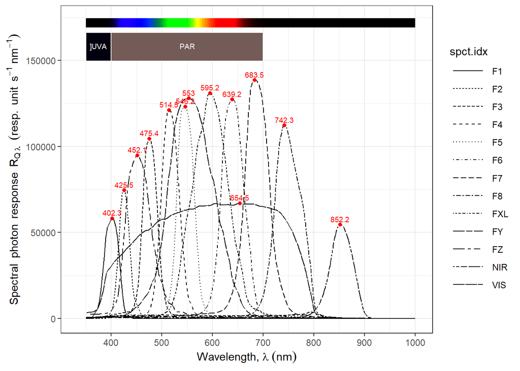

```r
autoplot(ams_AS7343.mspct, norm = "undo")
```

## Hourly sunlight spectra

```r
load("kumpula-all-hourly-mspct-anders-lindfors.rda")
test.hourly.mspct <- all_hourly.mspct
length(all_hourly.mspct)
```

```
## [1] 11768
```

```r
test.hourly.mspct <-
  test.hourly.mspct[sample(seq_along(all_hourly.mspct), 100)]
```

## Assorted greenhouse spectra

```r
load("greenhouse-mspct.rda")
length(greenhouse.mspct)
```

```
## [1] 24
```

```r
test.mspct <- c(greenhouse.mspct, test.hourly.mspct)
length(test.mspct)
```

```
## [1] 124
```

```r
my.default.alpha = 0.25
```

## Simulated calibration

With a list of `waveband` objects we can compute multiple irradiances by integrating the radiation spectrum over multiple ranges of wavelengths.

```r
extra.wavebands <-
  c(Plant_bands("Sellaro"),
    list(Red("Smith20"), Far_red("Smith20")))
```

Compute irradiances

```r
irradiances.tb <-
  xPAR_irrad(test.mspct,
             w.band = Plant_bands("Sellaro"),
             scale.factor = 1e6, # mol m-2 s-1 -> umol m-2 s-1
             return.tb = TRUE)
nrow(irradiances.tb)
```

```
## [1] 124
```

```r
ncol(irradiances.tb)
```

```
## [1] 13
```

```r
channels.ls <-list()
spct.names <- names(test.mspct)
for (name in spct.names) {
#  print(name)
  temp.tb <-simul_AS7343(test.mspct[[name]][ , 1:2])
  channels.ls[[name]] <- temp.tb[[2]]
}
channels.tb <- as.data.frame(t(as.data.frame(channels.ls)))
colnames(channels.tb) <- temp.tb[["spct.idx"]]
channels.tb[["spct.idx"]] <- spct.names
```

It is safer to join the irradiance and sensor response data matching rows by spectrum name than by position.

```r
colnames(irradiances.tb)
```

```
##  [1] "spct.idx"         "Q_xPAR"           "Q_ePAR"           "Q_PAR"
##  [5] "Q_FR.700.750"     "Q_UVB.ISO"        "Q_UVA2.CIE"       "Q_UVA1.CIE"
##  [9] "Q_Blue.Sellaro"   "Q_Green.Sellaro"  "Q_Red.Sellaro"    "Q_FarRed.Sellaro"
## [13] "Q_]UVB.ISO"
```

```r
colnames(channels.tb)
```

```
##  [1] "F1"       "F2"       "F3"       "F4"       "F5"       "F6"
##  [7] "F7"       "F8"       "FXL"      "FY"       "FZ"       "NIR"
## [13] "VIS"      "spct.idx"
```

```r
all_data.tb <- right_join(irradiances.tb, channels.tb)
PfrPtot <- numeric()
idx <- 0
spct.names <- names(test.mspct)
for (name in spct.names) {
  idx <- idx + 1L
#  print(name)
  PfrPtot[idx] <- Pfr_Ptot(test.mspct[[name]][ , 1:2])
}
all_data.tb[["Pfr.Ptot"]] <- PfrPtot
```

```r
save(all_data.tb, file = "all-hourly-summaries.rda")
```

### PAR

The first question is: Is the VIS channel corrected with FR channel *FF8* a good enough match to be used for PAR measurements?

```
## SMA/MA, band is currently for slope only!
```

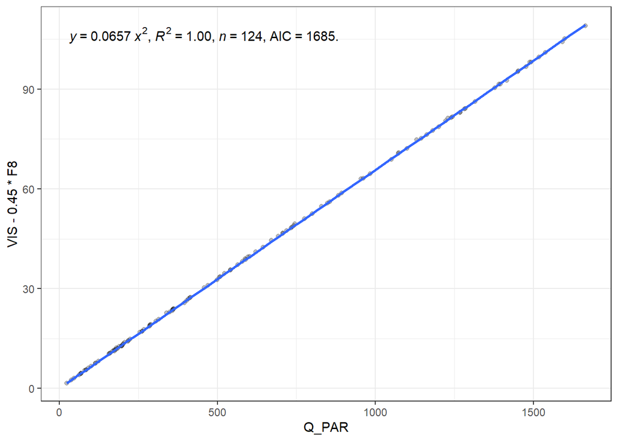

```r
ggplot(all_data.tb, aes(Q_PAR, VIS - 0.45 * F8)) +
  geom_point(alpha = my.default.alpha) +
  stat_poly_line(formula = y ~ x + 0, method = "sma") +
  stat_poly_eq(use_label("eq", "R2", "n", "AIC"),
               formula = y ~ x + 0, method = "sma")
```

### ePAR

Would it also work for ePAR?

```
## SMA/MA, band is currently for slope only!
```

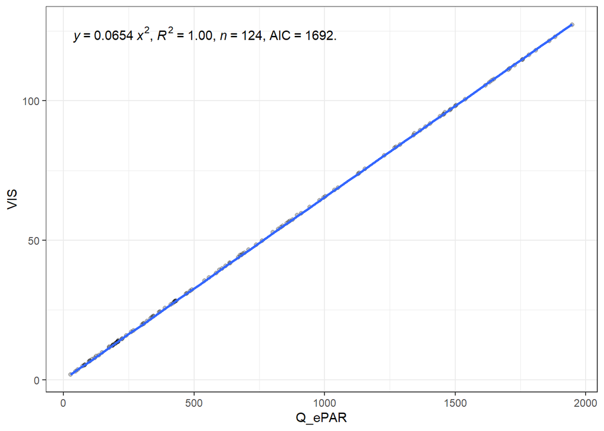

```r
ggplot(all_data.tb, aes(Q_ePAR, VIS)) +
  geom_point(alpha = my.default.alpha) +
  stat_poly_line(formula = y ~ x + 0, method = "sma") +
  stat_poly_eq(use_label("eq", "R2", "n", "AIC"),
               formula = y ~ x + 0, method = "sma")
```

For sunlight the answer to both questions is: yes.

### UVA1

```
## SMA/MA, band is currently for slope only!
```

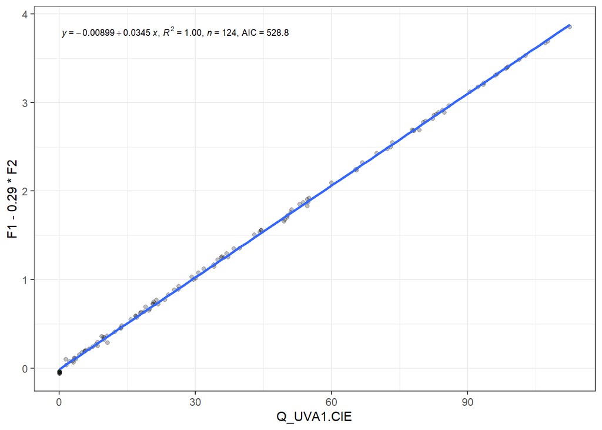

```r
ggplot(all_data.tb, aes(Q_UVA1.CIE, F1 - 0.29 * F2)) +
  geom_point(alpha = my.default.alpha) +
  stat_poly_line(formula = y ~ x, method = "sma") +
  stat_poly_eq(use_label("eq", "R2", "n", "AIC"),
               formula = y ~ x, method = "sma",
               size = 2.7)
```

### UVA1:PAR photon ratio

```
## SMA/MA, band is currently for slope only!
```

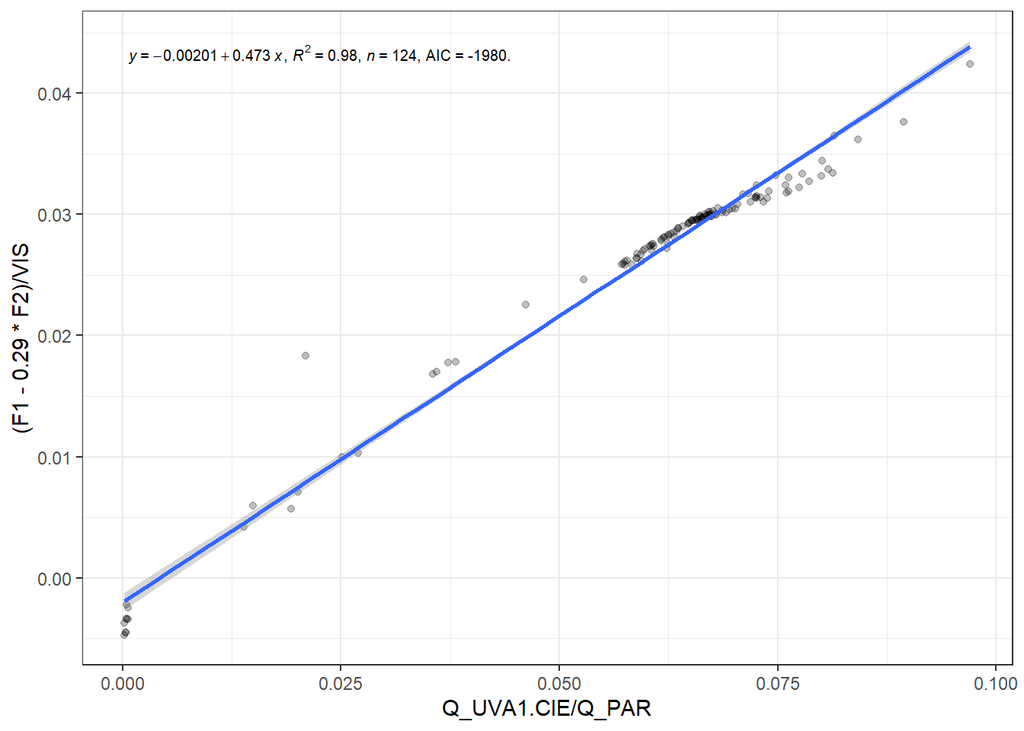

```r
ggplot(all_data.tb, aes(Q_UVA1.CIE / Q_PAR, (F1 - 0.29 * F2) / VIS)) +
  geom_point(alpha = my.default.alpha) +
  stat_poly_line(formula = y ~ x, method = "sma") +
  stat_poly_eq(use_label("eq", "R2", "n", "AIC"),
               formula = y ~ x, method = "sma",
               size = 2.7)
```

### Blue

```
## SMA/MA, band is currently for slope only!
```

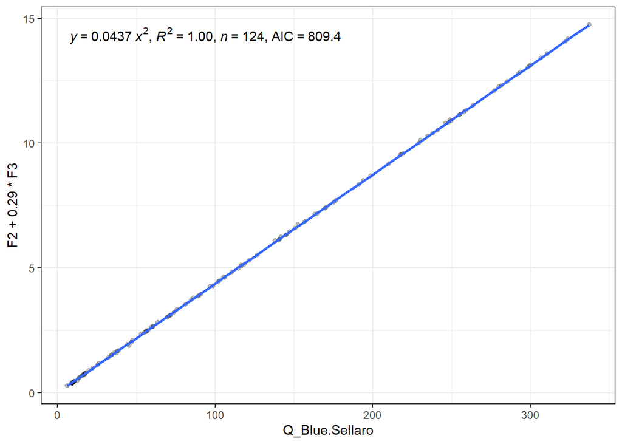

```r
ggplot(all_data.tb, aes(Q_Blue.Sellaro, F2 + 0.29 * F3)) +
  geom_point(alpha = my.default.alpha) +
  stat_poly_line(formula = y ~ x + 0, method = "sma") +
  stat_poly_eq(use_label("eq", "R2", "n", "AIC"),
               formula = y ~ x + 0, method = "sma")
```

### Green

```
## SMA/MA, band is currently for slope only!
```

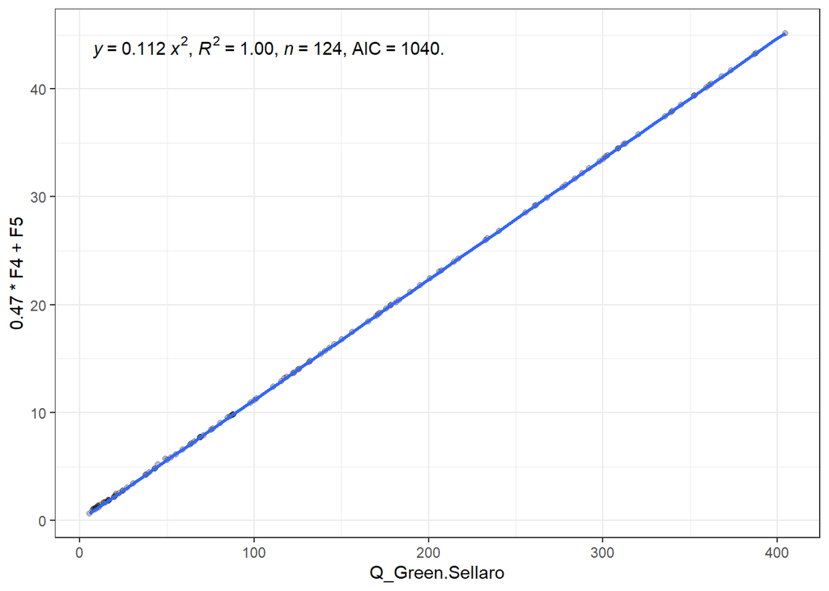

```r
ggplot(all_data.tb, aes(Q_Green.Sellaro, 0.47 * F4 + F5)) +
  geom_point(alpha = my.default.alpha) +
  stat_poly_line(formula = y ~ x + 0, method = "sma") +
  stat_poly_eq(use_label("eq", "R2", "n", "AIC"),
               formula = y ~ x + 0, method = "sma")
```

### B:G photon ratio

```
## SMA/MA, band is currently for slope only!
```

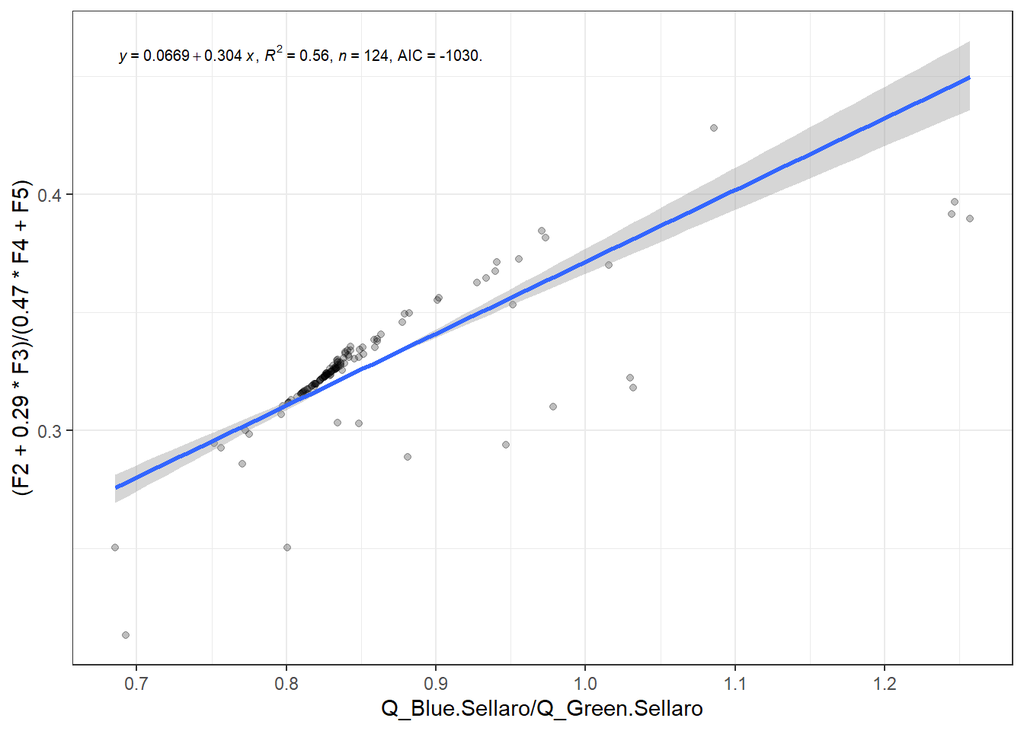

```r
ggplot(all_data.tb, aes(Q_Blue.Sellaro / Q_Green.Sellaro,
                        (F2 + 0.29 * F3) / (0.47 * F4 + F5))) +
  geom_point(alpha = my.default.alpha) +
  stat_poly_line(formula = y ~ x, method = "sma") +
  stat_poly_eq(use_label("eq", "R2", "n", "AIC"),
               formula = y ~ x, method = "sma",
               size = 2.7)
```

### Red

```
## SMA/MA, band is currently for slope only!
```

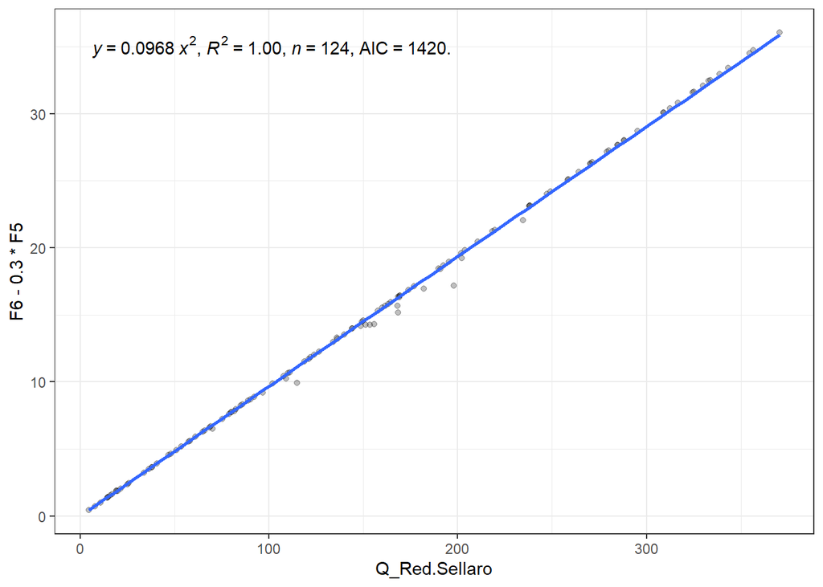

```r
ggplot(all_data.tb, aes(Q_Red.Sellaro, F6 - 0.3 * F5)) +
  geom_point(alpha = my.default.alpha) +
  stat_poly_line(formula = y ~ x + 0, method = "sma") +
  stat_poly_eq(use_label("eq", "R2", "n", "AIC"),
               formula = y ~ x + 0, method = "sma")
```

### Far Red

```
## SMA/MA, band is currently for slope only!
```

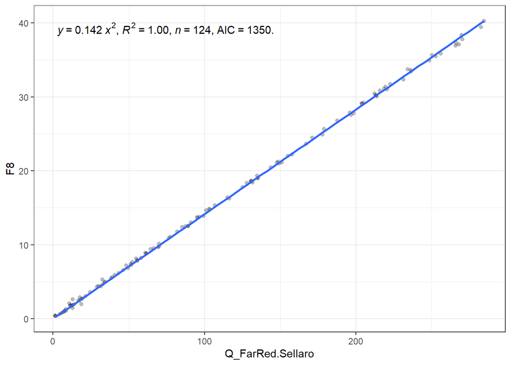

```r
ggplot(all_data.tb, aes(Q_FarRed.Sellaro, F8)) +
  geom_point(alpha = my.default.alpha) +
  stat_poly_line(formula = y ~ x + 0, method = "sma") +
  stat_poly_eq(use_label("eq", "R2", "n", "AIC"),
               formula = y ~ x + 0, method = "sma")
```

### FR:R+FR photon fraction

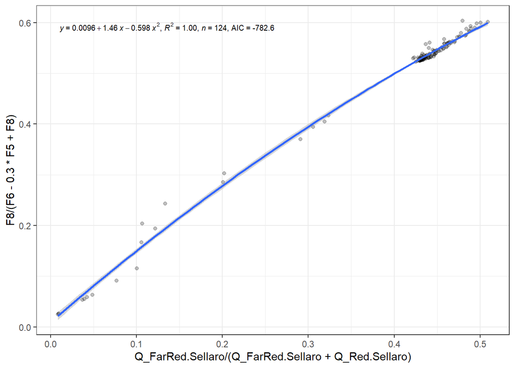

```r
ggplot(all_data.tb, aes(Q_FarRed.Sellaro / (Q_FarRed.Sellaro + Q_Red.Sellaro), F8 / (F6 - 0.3 * F5 + F8))) +
  geom_point(alpha = my.default.alpha) +
  stat_poly_line(formula = y ~ x + I(x^2), method = "lm") +
  stat_poly_eq(use_label("eq", "R2", "n", "AIC"),
               formula = y ~ x + I(x^2), method = "lm",
               size = 2.7)
```

The range of meaningful values for R:FR in sunlight is narrow and consequently small errors in the quantification of R and/or FR irradiance result in R:FR errors that can be thought as important for plant responses. Possibly, more important, is that the R:FR photon ratio measured based on different waveband definitions is not consistent in sunlight.

The choice of wavebands is rather arbitrary as the Pfr:Ptot fraction depends on a broad range of wavelengths and different wavelengths affect it with different weights.

### FR:ePAR photon fraction

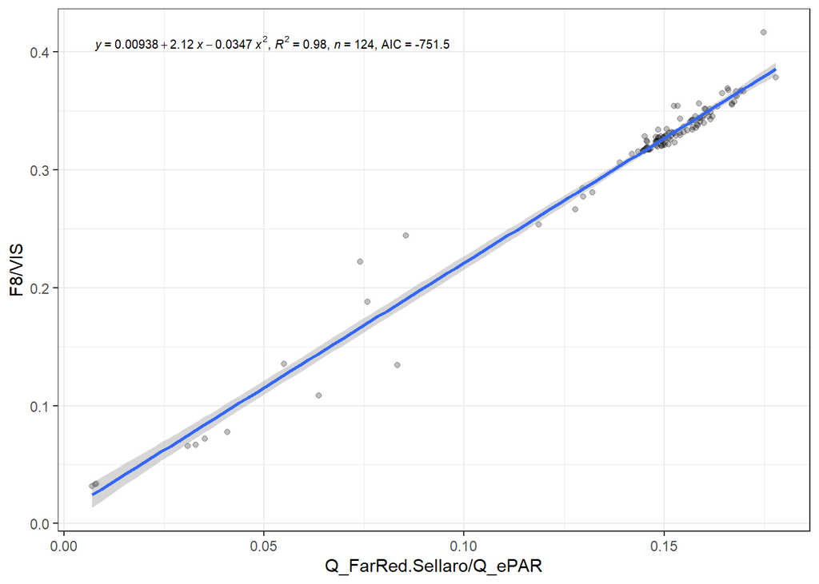

```r
ggplot(all_data.tb, aes(Q_FarRed.Sellaro / Q_ePAR, F8 / VIS)) +
  geom_point(alpha = my.default.alpha) +
  stat_poly_line(formula = y ~ x + I(x^2), method = "lm") +
  stat_poly_eq(use_label("eq", "R2", "n", "AIC"),
               formula = y ~ x + I(x^2), method = "lm",
               size = 2.7)
```

### FR:PAR photon fraction

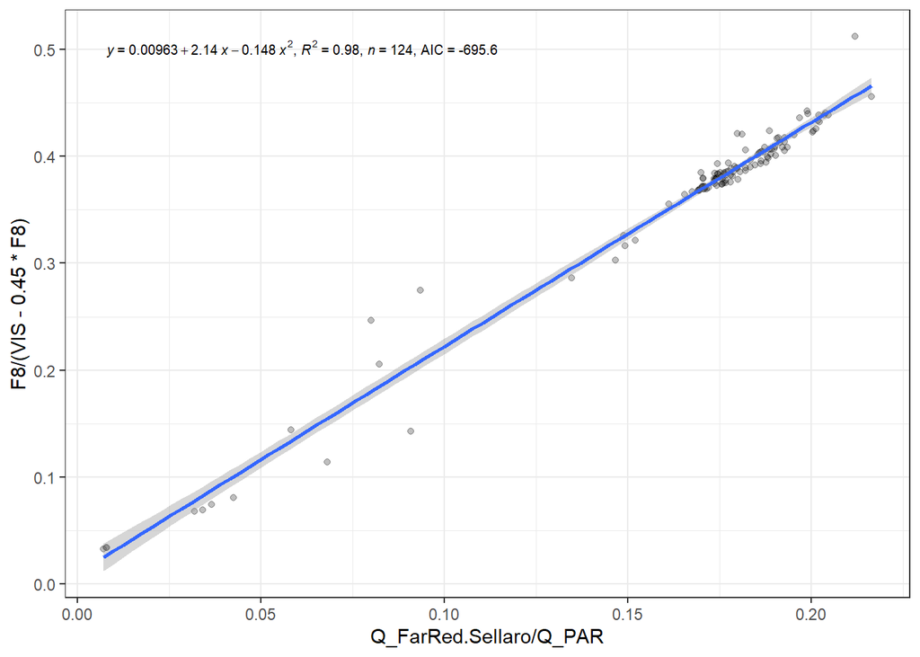

```r
ggplot(all_data.tb,
       aes(Q_FarRed.Sellaro / Q_PAR, F8 / (VIS - 0.45 * F8))) +
  geom_point(alpha = my.default.alpha) +
  stat_poly_line(formula = y ~ x + I(x^2), method = "lm") +
  stat_poly_eq(use_label("eq", "R2", "n", "AIC"),
               formula = y ~ x + I(x^2), method = "lm",
               size = 2.7)
```

### Pfr:Ptot vs. FR fraction

```
## SMA/MA, band is currently for slope only!
```

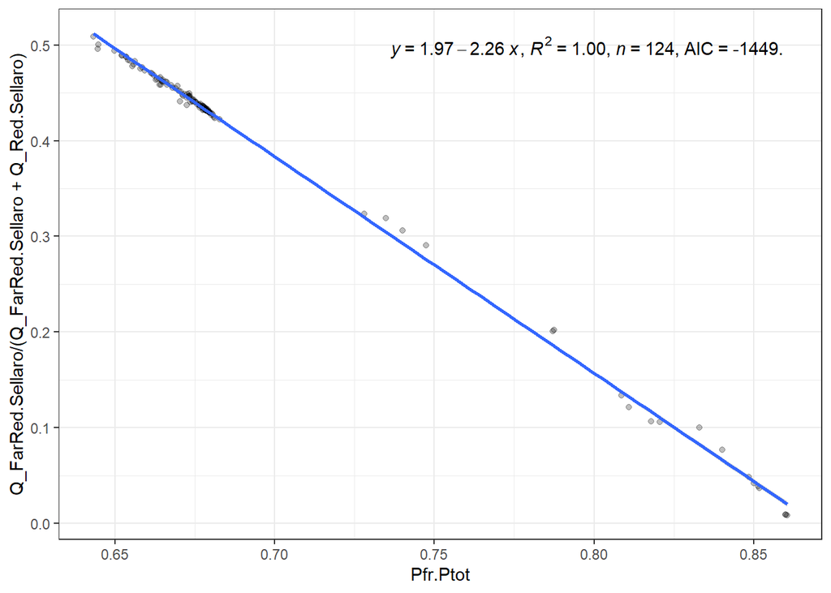

```r
ggplot(all_data.tb, aes(Pfr.Ptot,
                        Q_FarRed.Sellaro / (Q_FarRed.Sellaro + Q_Red.Sellaro))) +
  geom_point(alpha = my.default.alpha) +
  stat_poly_line(formula = y ~ x, method = "sma") +
  stat_poly_eq(use_label("eq", "R2", "n", "AIC"),
               label.x = "right",
               formula = y ~ x, method = "sma")
```

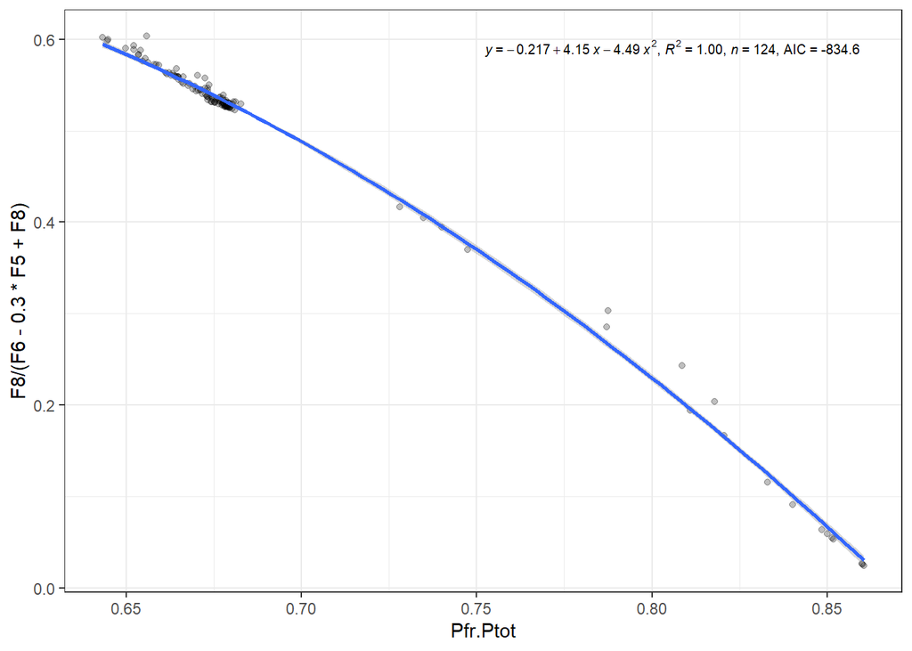

```r
ggplot(all_data.tb, aes(Pfr.Ptot, F8 / (F6 - 0.3 * F5 + F8))) +
  geom_point(alpha = my.default.alpha) +
  stat_poly_line(formula = y ~ x + I(x^2), method = "lm") +
  stat_poly_eq(use_label("eq", "R2", "n", "AIC"),
               label.x = "right",
               formula = y ~ x + I(x^2), method = "lm",
               size = 2.7)
```